# Regional Housing Framework

Clean node geographies

Library: RegHsg

Project: Regional Housing Framework

Author: Sarah Strochak

Version: R 3.5.2, RStudio 1.1.423

Last updated February 27, 2019

Environment: Local Windows session (desktop)

## Description

The purpose of this program is to walk through the process of creating the buffered geographical data layers that will be used in the upzoning analysis.

## Set-up

Load libraries and functions

```r
library(tidyverse)
library(sf)
library(urbnthemes)
library(units)
```

## Geospatial data-wrangling

Read in the COG boundary, and set the CRS to 4326.

```r
regdir <- "L:/Libraries/Region/Maps"

bound <- st_read(dsn = regdir,
                 layer = "Mapping_Boundaries__COG_Members") %>%
  st_transform(crs = 4326)
```

### Transit

Read in VRE, MARC, Metro, Amtrak, Purple line, and Loudoun metro expansion stations. Reproject them into CRS 4326. Standardize them so they all have the same variables:

- `type` indicates which type of rail they are (Metro vs. MARC vs. VRE, etc)
- `name` is the station name
- `line` indicates which line- this could be important if we want to distinguish routes, or between stations that are built vs. lines that are planned.

```r
rhfdir <- "L:/Libraries/RegHsg/Maps"

metro <- st_read(dsn = rhfdir,
                 layer = "Metro__Rail_Stations") %>%
  st_transform(crs = 4326) %>%
  mutate(type = "Metro") %>%
  select(type,
         name = NAME,
         line = LINE)

vre <- st_read(dsn = rhfdir,
               layer = "Virginia_Railway_Express_Stations") %>%
  st_transform(crs = 4326) %>%
  mutate(type = "VRE") %>%
  select(type,
         name = NAME,
         line = LINE)

pl <- st_read(dsn = rhfdir,
              layer = "purple_line_stops") %>%
  st_transform(crs = 4326) %>%
  mutate(type = "Purple line",
         line = "Purple") %>%
  select(type,
         name = NAME,
         line)

marc <- st_read(dsn = rhfdir,
                layer = "Maryland_Transit__MARC_Train_Stops") %>%
  st_transform(crs = 4326) %>%
  mutate(type = "MARC") %>%
  select(type,
         name = Name,
         line = Line_Name)

amtrak <- st_read(dsn = rhfdir,
                  layer = "Maryland_Transit__Amtrak_Rail_Stops") %>%
  st_transform(crs = 4326) %>%
  mutate(type = "Amtrak",
         line = "Amtrak") %>%
  select(type,
         name = STNNAME,
         line)

loud <- st_read(dsn = rhfdir,
                layer = "Loudoun_Metrorail_Stations_Planned") %>%
  st_transform(crs = 4326) %>%
  mutate(type = "Loudoun Metro extension",
         line = "Loudoun Metro extension") %>%
  select(type,
         name = MN_NAME,
         line)
```

Merge all the transit lines together into one object.

```r
transit <- rbind(amtrak,
                 loud,
                 marc,
                 metro,
                 pl,
                 vre) %>%
  mutate(type = factor(type,
                       levels = c("Metro",
                                  "VRE",
                                  "MARC",
                                  "Amtrak",
                                  "Purple line",
                                  "Loudoun Metro extension")))
```

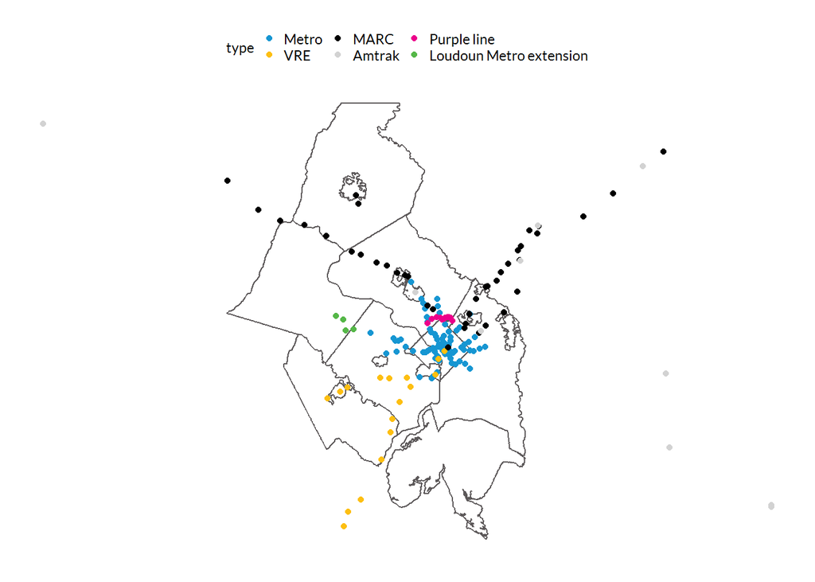

Create buffer around the stations. To do this, we re-project to feet, create the buffer, then re-project back to CRS = 4326. Test this out with a half mile buffer.

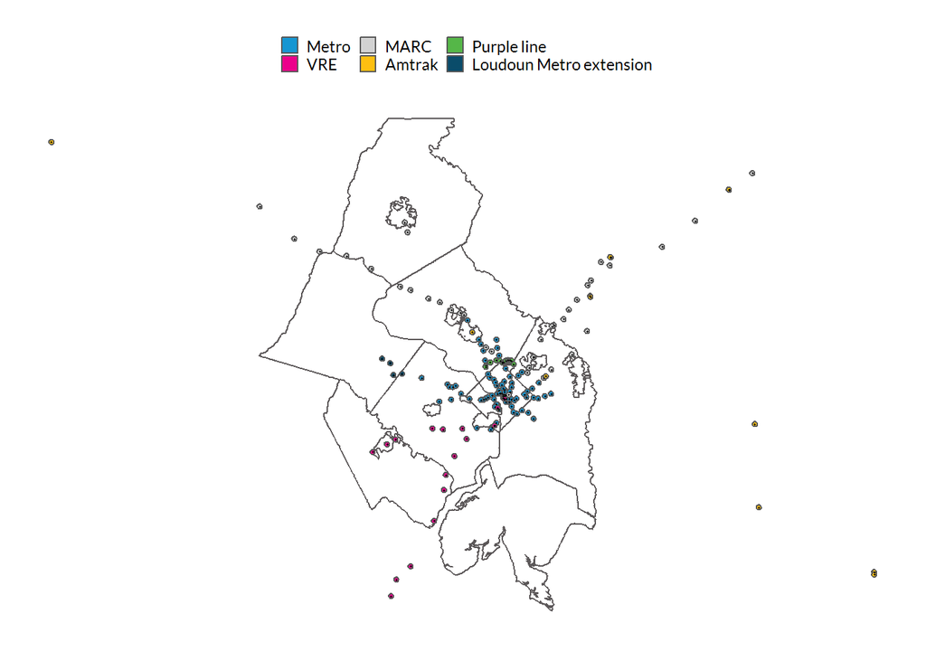

```r
# convert half mile to feet and set units
radius <- set_units(.5, mi) %>% set_units(ft)

# project to MD state plane in feet
transit_proj <- st_transform(transit, crs = 2248)

# calculate buffer, set CRS back to standard 4326
transit_buffer <- st_buffer(transit_proj, radius) %>%
  st_transform(crs = 4326)

# map activity centers back on top of buffer to visually confirm
ggplot() +
  geom_sf(data = bound, mapping = aes(),
          fill = NA, color = "#5c5859") +
  geom_sf(data = transit_buffer, mapping = aes(fill = type)) +
  scale_fill_manual(values = c("#1696d2", "#ec008b", "#d2d2d2",
                               "#fdbf11", "#55b748", "#0a4c6a")) +
  geom_sf(data = transit, mapping = aes(),
          color = "black", size = .25) +
  theme_urbn_map() +
  theme(legend.position = "top",
        legend.direction = "horizontal") +
  coord_sf(datum = NA) +
  labs(fill = NULL)
```

Zoom in on Arlington for a better view.

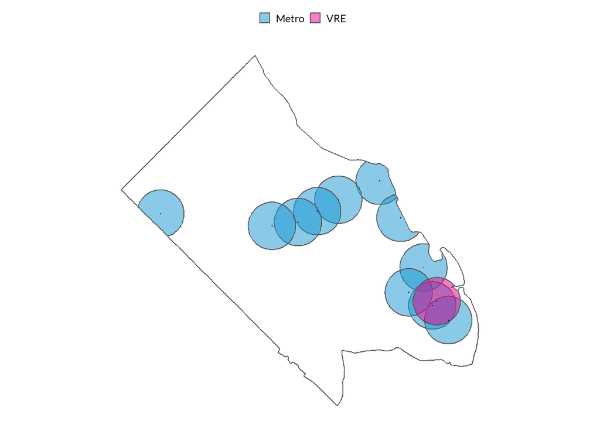

```r
arl <- bound %>%
  filter(COGNAME == "Arlington")

ggplot() +
  geom_sf(data = arl, mapping = aes(),
          fill = NA, color = "#5c5859") +
  geom_sf(data = st_intersection(transit_buffer, arl),
          mapping = aes(fill = type),
          alpha = .5) +
  scale_fill_manual(values = c("#1696d2", "#ec008b", "#d2d2d2",
                               "#fdbf11", "#55b748", "#0a4c6a")) +
  geom_sf(data = st_intersection(transit, arl),
          mapping = aes(),
          color = "black", size = .25) +
  theme_urbn_map() +
  theme(legend.position = "top",
        legend.direction = "horizontal") +
  coord_sf(datum = NA) +
  labs(fill = NULL)
```

### Activity centers

We will repeat a similar process for activity centers.

Read in COG activity centers, set CRS. We want the variables to be consistent with the transit lines- so we create the same variables:

- `type` will indicate “Activity”
- `name` will be the Activity center name
- `line` will be NA

```r
act <- st_centroid(st_read(dsn = regdir,
               layer = "Activity_Centers")) %>%
  st_transform(crs = 4326) %>%
  mutate(type = "Activity",
         line = NA) %>%
  select(name = Activity_C, type, line)
```

Map activity centers centroids.

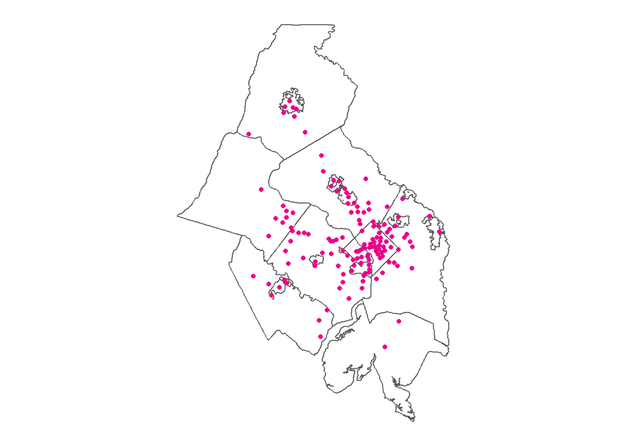

Create buffer around activity centers. Test this out with a 1 mile buffer.

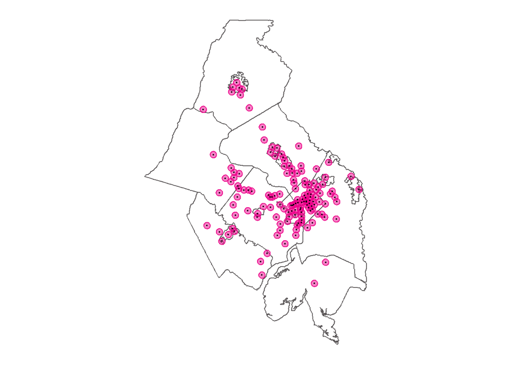

```r
# convert one mile to feet and set units
radius <- set_units(1, mi) %>% set_units(ft)

# project to MD state plane in feet
act_proj <- st_transform(act, crs = 2248)

# calculate buffer, set CRS back to standard 4326
act_buffer <- st_buffer(act_proj, radius) %>%
  st_transform(crs = 4326)

# map activity centers back on top of buffer to visually confirm
ggplot() +
  geom_sf(data = bound, mapping = aes(),
          fill = NA, color = "#5c5859") +
  geom_sf(data = act_buffer, mapping = aes(),
          fill = "#ec008b", color = "#ec008b", alpha = 0.5) +
  geom_sf(data = act, mapping = aes(),
          color = "black", size = .4) +
  theme_urbn_map() +
  coord_sf(datum = NA)
```

### Merge buffered zones

In the whole region, a lot of these zones will overlap, but we do not want to double count anything. We need to merge all the buffered zones into one giant blob.

Map them seperately

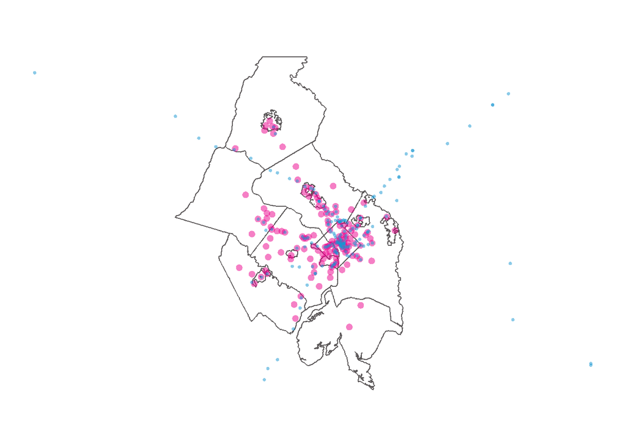

```r
ggplot() +
  geom_sf(data = bound, mapping = aes(),
          fill = NA, color = "#5c5859") +
  geom_sf(data = act_buffer, mapping = aes(),
          fill = "#ec008b", color = NA, alpha = 0.5) +
  geom_sf(data = transit_buffer, mapping = aes(),
          fill = "#1696d2", color = NA, alpha = 0.5) +
  theme_urbn_map() +
  coord_sf(datum = NA)
```

Use `st_union()` to merge them into one giant shape

```r
act_transit <- rbind(act_buffer, transit_buffer)

upzone_area <- st_union(act_transit)
```

Plot for the whole region, zoom in on Arlington for more detail.

##### Region

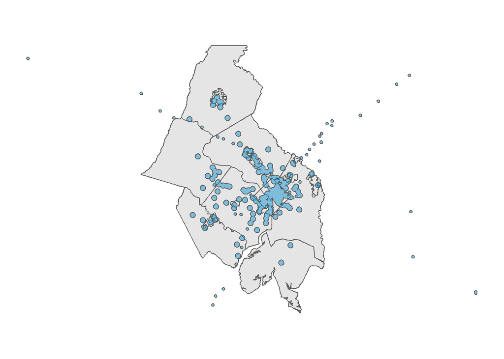

##### Arlington

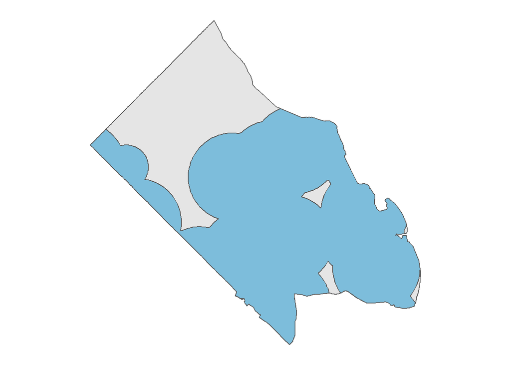

## Parameterize buffer creation

There are a number of combinations of buffer sizes that we will need. In order to accomodate this, we can parametrize the above process. See `"Macros/get_node_geography.R"`.

```r
source("../Macros/get_node_geography.R")
```

#### Example function use

The following examples show two of the many ways we can use this function to get the geographies we need.

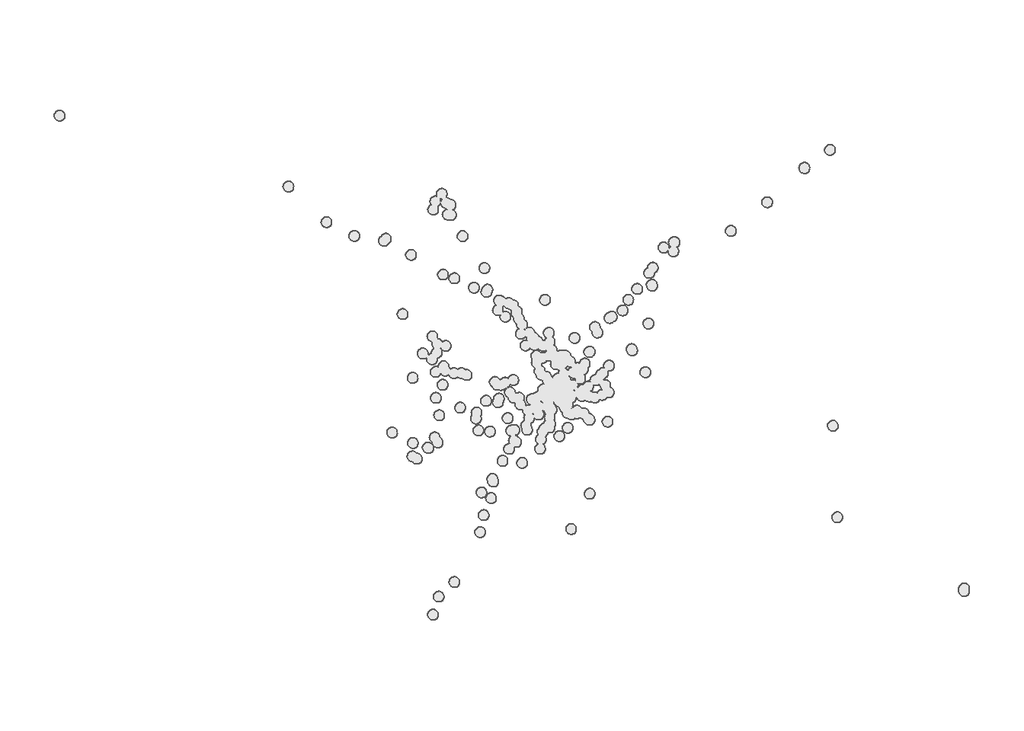

```r
activity_buffered <- get_node_geography(node_type = "activity",
                                       style = "buffer",
                                       activity_buffer = 1)


get_node_geography(node_type = "joint",
                   style = "buffer-union",
                   activity_buffer = 1,
                   transit_buffer = 1) %>%
  ggplot() +
  geom_sf(mapping = aes()) +
  theme_urbn_map() +
  coord_sf(datum = NA)
```